# Machine Learning Assingment

Francisco Mimica Porras

4/6/2021

#Introduction

Using devices such as Jawbone Up, Nike FuelBand, and Fitbit it is now possible to collect a large amount of data about personal activity relatively inexpensively. These type of devices are part of the quantified self movement – a group of enthusiasts who take measurements about themselves regularly to improve their health, to find patterns in their behavior, or because they are tech geeks. One thing that people regularly do is quantify how much of a particular activity they do, but they rarely quantify how well they do it. In this project, your goal will be to use data from accelerometers on the belt, forearm, arm, and dumbell of 6 participants. They were asked to perform barbell lifts correctly and incorrectly in 5 different ways. More information is available from the website here: [http://web.archive.org/web/20161224072740/http:/groupware.les.inf.puc-rio.br/har] (see the section on the Weight Lifting Exercise Dataset).

#Data

The training data for this project are available here:

[https://d396qusza40orc.cloudfront.net/predmachlearn/pml-training.csv]

The test data are available here:

[https://d396qusza40orc.cloudfront.net/predmachlearn/pml-testing.csv]

The data for this project come from this source: [http://groupware.les.inf.puc-rio.br/har]. If you use the document you create for this class for any purpose please cite them as they have been very generous in allowing their data to be used for this kind of assignment.

# Processing Data

Loaded databases from website: training and testing.

```r
trainingweb <- "http://d396qusza40orc.cloudfront.net/predmachlearn/pml-training.csv"
training <- read.csv(url(trainingweb), na.strings=c("NA","#DIV/0!",""),header=TRUE)
testingweb <- "http://d396qusza40orc.cloudfront.net/predmachlearn/pml-testing.csv"
testing <- read.csv(url(testingweb),na.strings=c("NA","#DIV/0!",""),header=TRUE)
cbind(dim(training),dim(testing))
```

```
##       [,1] [,2]
## [1,] 19622   20
## [2,]   160  160
```

Training dataset: 19622 observations and 160 variables. Testing dataset: 20 observations and 160 variables.

# Data Cleaning

Step 1: Removing predictors with low variability.

These datasets, training and testing, have 160 variables each. the first step is identify the variables are not contributing with variability to the model. I will use the “nearZerovar” function for this process. It will not only removes predictors that have one unique value across samples (zero variance predictors), but also removes predictors that have both 1) few unique values relative to the number of samples and 2) large ratio of the frequency of the most common value to the frequency of the second most common value (near-zero variance predictors)

```r
library(lattice)
library(ggplot2)
library(caret)
zvartraining <- nearZeroVar(training)
training_zvar <- training[,-zvartraining]
testing_zvar <- testing[,-zvartraining]
cbind(dim(training_zvar), dim(testing_zvar))
```

```
##       [,1] [,2]
## [1,] 19622   20
## [2,]   124  124
```

Training dataset: 19622 observations and 124 variables. Testing dataset: 20 observations and 124 variables.

Step 2: Removing predictors with high missing value rate.

```r
na_col_training <- sapply(training_zvar, function(x) mean(is.na(x))) > 0.95 # threshold is 95%
training_zvar <- training_zvar[,na_col_training == FALSE]
testing_zvar <- testing_zvar[,na_col_training == FALSE]
cbind(dim(training_zvar), dim(testing_zvar))
```

```
##       [,1] [,2]
## [1,] 19622   20
## [2,]    59   59
```

Training dataset: 19622 observations and 59 variables. Testing dataset: 20 observations and 59 variables

Step 3: Removing identifiers (1 to 7)

```r
training_zvar <- training_zvar[, -(1:7)]
testing_zvar  <- testing_zvar[, -(1:7)]
cbind(dim(training_zvar), dim(testing_zvar))
```

```
##       [,1] [,2]
## [1,] 19622   20
## [2,]    52   52
```

Training_zvar dataset: 19622 observations and 52 variables. Testing_zvar dataset: 20 observations and 52 variables

## Partitioning

The training_zvar will be split our in the training (60% of the total data) and testing sets (40% of the total data).

```r
inTrain <- createDataPartition(training_zvar$classe, p=0.6, list=FALSE)
training.Model <- training_zvar[inTrain,]
testing.Model <- training_zvar[-inTrain,]
cbind(dim(training.Model),dim(testing.Model))
```

```
##       [,1] [,2]
## [1,] 11776 7846
## [2,]    52   52
```

```r
table(training.Model$classe)
```

```
##
##    A    B    C    D    E
## 3348 2279 2054 1930 2165
```

```r
table(testing.Model$classe)
```

```
##
##    A    B    C    D    E
## 2232 1518 1368 1286 1442
```

Training.Model dataset: 11776 observations and 52 variables. Testing.Model dataset: 7846 observations and 52 variables

## Model Selection

### Tree Model (TM)

```r
library(lattice)
library(ggplot2)
library(caret)
TM_modfit<- train(classe ~ ., method="rpart", data = training.Model)
print(TM_modfit$finalModel)
```

```
## n= 11776
##
## node), split, n, loss, yval, (yprob)
##       * denotes terminal node
##
##  1) root 11776 8428 A (0.28 0.19 0.17 0.16 0.18)
##    2) pitch_forearm< -33.95 942    6 A (0.99 0.0064 0 0 0) *
##    3) pitch_forearm>=-33.95 10834 8422 A (0.22 0.21 0.19 0.18 0.2)
##      6) accel_belt_z>=-187.5 10193 7785 A (0.24 0.22 0.2 0.19 0.15)
##       12) magnet_dumbbell_y< 426.5 8427 6088 A (0.28 0.17 0.23 0.19 0.13)
##         24) roll_forearm< 119.5 5189 3107 A (0.4 0.16 0.18 0.16 0.092) *
##         25) roll_forearm>=119.5 3238 2198 C (0.079 0.19 0.32 0.23 0.18)
##           50) accel_forearm_x>=-108.5 2336 1493 C (0.087 0.23 0.36 0.11 0.22) *
##           51) accel_forearm_x< -108.5 902  428 D (0.06 0.099 0.22 0.53 0.098) *
##       13) magnet_dumbbell_y>=426.5 1766  957 B (0.039 0.46 0.042 0.2 0.26) *
##      7) accel_belt_z< -187.5 641    5 E (0.0062 0.0016 0 0 0.99) *
```

```r
library(tibble)
library(bitops)
library(rattle)
TM_prediction <- predict(TM_modfit, newdata= testing.Model)
confusionMatrix(TM_prediction,as.factor(testing.Model$classe))
```

```
## Confusion Matrix and Statistics
##
##           Reference
## Prediction    A    B    C    D    E
##          A 2013  608  625  541  333
##          B   54  539   54  258  317
##          C  130  330  543  186  328
##          D   33   41  146  301   72
##          E    2    0    0    0  392
##
## Overall Statistics
##
##                Accuracy : 0.4828
##                  95% CI : (0.4717, 0.4939)
##     No Information Rate : 0.2845
##     P-Value [Acc > NIR] : < 2.2e-16
##
##                   Kappa : 0.3241
##
##  Mcnemar's Test P-Value : < 2.2e-16
##
## Statistics by Class:
##
##                      Class: A Class: B Class: C Class: D Class: E
## Sensitivity            0.9019   0.3551  0.39693  0.23406  0.27184
## Specificity            0.6247   0.8921  0.84964  0.95549  0.99969
## Pos Pred Value         0.4886   0.4411  0.35794  0.50759  0.99492
## Neg Pred Value         0.9412   0.8522  0.86965  0.86419  0.85910
## Prevalence             0.2845   0.1935  0.17436  0.16391  0.18379
## Detection Rate         0.2566   0.0687  0.06921  0.03836  0.04996
## Detection Prevalence   0.5251   0.1557  0.19335  0.07558  0.05022
## Balanced Accuracy      0.7633   0.6236  0.62329  0.59477  0.63577
```

Plotting Tree Model

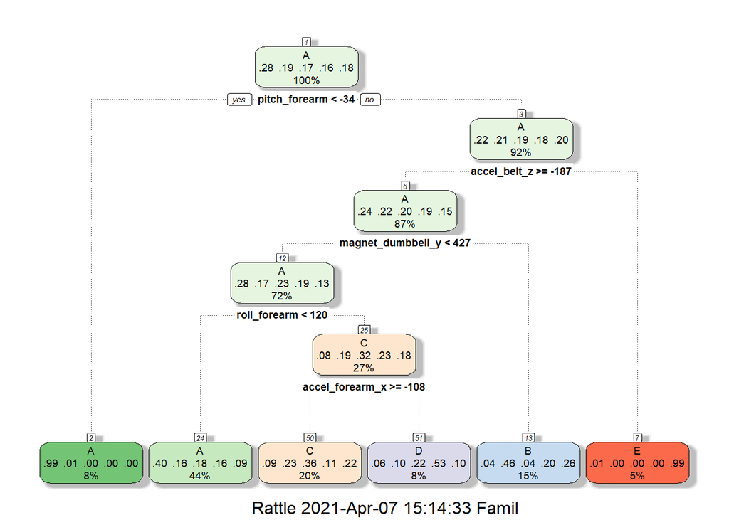

```r
fancyRpartPlot(TM_modfit$finalModel)
```

### Random Forest Model (RFM)

```r
RFM_modfit <- train(classe ~ ., data = training.Model, method = "rf", ntree = 100)
RFM_modfit
```

```
## Random Forest
##
## 11776 samples
##    51 predictor
##     5 classes: 'A', 'B', 'C', 'D', 'E'
##
## No pre-processing
## Resampling: Bootstrapped (25 reps)
## Summary of sample sizes: 11776, 11776, 11776, 11776, 11776, 11776, ...
## Resampling results across tuning parameters:
##
##   mtry  Accuracy   Kappa
##    2    0.9833793  0.9789614
##   26    0.9852609  0.9813445
##   51    0.9772892  0.9712565
##
## Accuracy was used to select the optimal model using the largest value.
## The final value used for the model was mtry = 26.
```

```r
print(RFM_modfit$finalModel)
```

```
##
## Call:
##  randomForest(x = x, y = y, ntree = 100, mtry = param$mtry)
##                Type of random forest: classification
##                      Number of trees: 100
## No. of variables tried at each split: 26
##
##         OOB estimate of  error rate: 1.01%
## Confusion matrix:
##      A    B    C    D    E class.error
## A 3341    5    1    0    1 0.002090800
## B   23 2239   14    1    2 0.017551558
## C    0   23 2026    5    0 0.013631938
## D    0    0   30 1898    2 0.016580311
## E    0    2    4    6 2153 0.005542725
```

```r
RFM_prediction <- predict(RFM_modfit, testing.Model)
RFM_pred_conf <- confusionMatrix(RFM_prediction, as.factor(testing.Model$classe))
RFM_pred_conf
```

```
## Confusion Matrix and Statistics
##
##           Reference
## Prediction    A    B    C    D    E
##          A 2226   17    0    0    0
##          B    4 1495   13    1    0
##          C    2    5 1351   19    3
##          D    0    1    4 1266    0
##          E    0    0    0    0 1439
##
## Overall Statistics
##
##                Accuracy : 0.9912
##                  95% CI : (0.9889, 0.9932)
##     No Information Rate : 0.2845
##     P-Value [Acc > NIR] : < 2.2e-16
##
##                   Kappa : 0.9889
##
##  Mcnemar's Test P-Value : NA
##
## Statistics by Class:
##
##                      Class: A Class: B Class: C Class: D Class: E
## Sensitivity            0.9973   0.9848   0.9876   0.9844   0.9979
## Specificity            0.9970   0.9972   0.9955   0.9992   1.0000
## Pos Pred Value         0.9924   0.9881   0.9790   0.9961   1.0000
## Neg Pred Value         0.9989   0.9964   0.9974   0.9970   0.9995
## Prevalence             0.2845   0.1935   0.1744   0.1639   0.1838
## Detection Rate         0.2837   0.1905   0.1722   0.1614   0.1834
## Detection Prevalence   0.2859   0.1928   0.1759   0.1620   0.1834
## Balanced Accuracy      0.9971   0.9910   0.9915   0.9918   0.9990
```

Plotting Random Forest Model

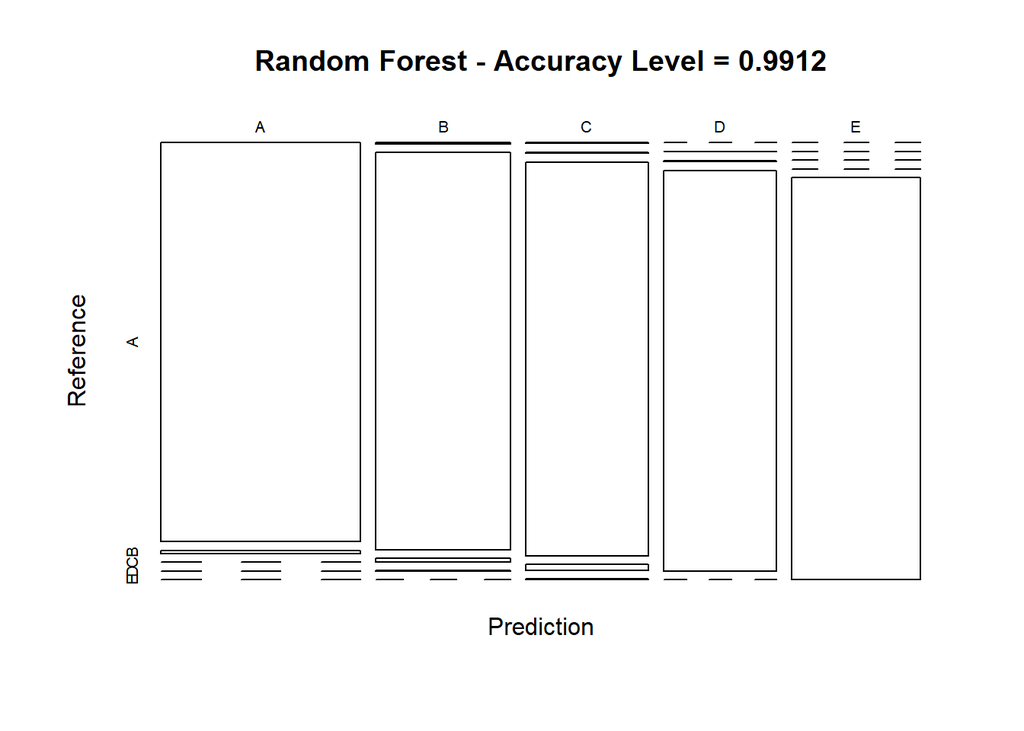

```r
plot(RFM_pred_conf$table, col = RFM_pred_conf$byClass,
     main = paste("Random Forest - Accuracy Level =",
                  round(RFM_pred_conf$overall['Accuracy'], 4)))
```

### Gradient Boosting Model (GBM)

```r
GBM_modfit <- train(classe ~ ., data = training.Model, method = "gbm", verbose = FALSE)
GBM_modfit$finalModel
```

```
## A gradient boosted model with multinomial loss function.
## 150 iterations were performed.
## There were 51 predictors of which 51 had non-zero influence.
```

```r
GBM_prediction <- predict(GBM_modfit, testing.Model)
GBM_pred_conf <- confusionMatrix(GBM_prediction,as.factor(testing.Model$classe))
GBM_pred_conf
```

```
## Confusion Matrix and Statistics
##
##           Reference
## Prediction    A    B    C    D    E
##          A 2181   56    0    0    1
##          B   29 1411   48    6   26
##          C   15   45 1289   48   14
##          D    3    1   25 1219   19
##          E    4    5    6   13 1382
##
## Overall Statistics
##
##                Accuracy : 0.9536
##                  95% CI : (0.9487, 0.9582)
##     No Information Rate : 0.2845
##     P-Value [Acc > NIR] : < 2.2e-16
##
##                   Kappa : 0.9413
##
##  Mcnemar's Test P-Value : 9.257e-09
##
## Statistics by Class:
##
##                      Class: A Class: B Class: C Class: D Class: E
## Sensitivity            0.9772   0.9295   0.9423   0.9479   0.9584
## Specificity            0.9898   0.9828   0.9812   0.9927   0.9956
## Pos Pred Value         0.9745   0.9283   0.9135   0.9621   0.9801
## Neg Pred Value         0.9909   0.9831   0.9877   0.9898   0.9907
## Prevalence             0.2845   0.1935   0.1744   0.1639   0.1838
## Detection Rate         0.2780   0.1798   0.1643   0.1554   0.1761
## Detection Prevalence   0.2852   0.1937   0.1798   0.1615   0.1797
## Balanced Accuracy      0.9835   0.9561   0.9617   0.9703   0.9770
```

Plotting Gradient Boosting Model

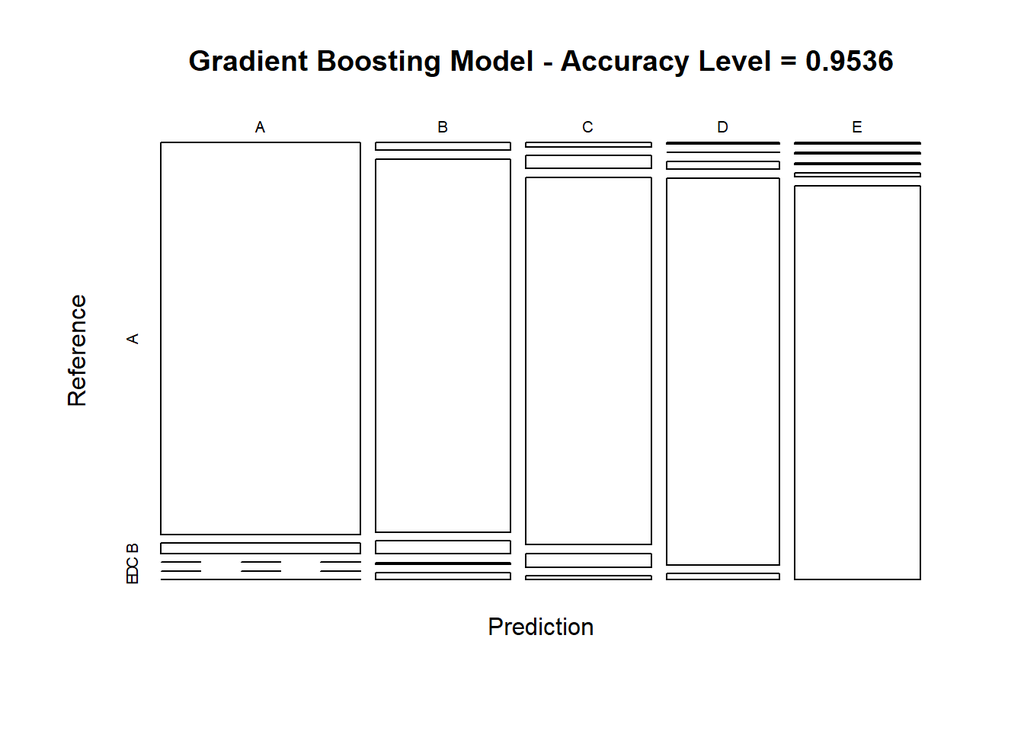

```r
plot(GBM_pred_conf$table, col = GBM_pred_conf$byClass,
     main = paste("Gradient Boosting Model - Accuracy Level =",
                  round(GBM_pred_conf$overall['Accuracy'], 4)))
```

The Tree model has not achieved the prediction accuracy level in order to be included in the next analysis. The final models selected with high prediction accuracy levels are the Gradient Boosting and Random Forest models.

### Final Comparison Between Gradient Boosting and Random Forest models.

```r
rbind(RFM_pred_conf$overall,GBM_pred_conf$overall)
```

```
##       Accuracy     Kappa AccuracyLower AccuracyUpper AccuracyNull
## [1,] 0.9912057 0.9888742     0.9888833     0.9931513    0.2844762
## [2,] 0.9536069 0.9413134     0.9487177     0.9581555    0.2844762
##      AccuracyPValue McnemarPValue
## [1,]              0           NaN
## [2,]              0  9.257349e-09
```

### Validation:

I will use the selected model for the final prediction. The utilized data is testing_zvar.

```r
Final_Validation_Model <- predict(RFM_modfit, testing_zvar)
Final_Validation_Model
```

```
##  [1] B A B A A E D B A A B C B A E E A B B B
## Levels: A B C D E
```